# Prediction Assignment

Boodeo Nem

January 8, 2019

#### Introduction

In this project, data from accelerometers on the belt, forearm, arm, and dumbell of 6 male participants who were asked to perform barbell lifts correctly and incorrectly in 5 different ways have been used to predict how “well” the exercise was performed. The predictions were based on different models (decision trees, linear discriminants and random forest) and the model giving the highest accuracy is the one built under random forest. Therefore, this model is proposed for making predictions based on the raw test sets.

#### Downloading the data

Both the training and testing data have been downloaded through the respective links. The training set has been used to build the model while the testing set was used to test the predictions by the models.

```r
library(caret); library(randomForest); library(rpart); library(rpart.plot)
if(!file.exists('data')) dir.create ('data')
fileUrl1 <- "https://d396qusza40orc.cloudfront.net/predmachlearn/pml-training.csv"
download.file(fileUrl1, destfile = "./data/predtraining.csv")
fileUrl2 <- "https://d396qusza40orc.cloudfront.net/predmachlearn/pml-testing.csv"
download.file(fileUrl2, destfile = "./data/predtest.csv")
trainset <- read.csv("C:/Users/boodeo1/Desktop/Coursera/data/data/predtraining.csv", na.strings = c("NA", "#DIV/0!", ""))
testset <- read.csv("C:/Users/boodeo1/Desktop/Coursera/data/data/predtest.csv", header = TRUE, sep = "")
```

After a quick observation of the data, all missing values and variables which are not relevant for the study are removed.

#### Cleaning the data

```r
# Deleting all missing values
set.seed(456)
trainset <- trainset[,colSums(is.na(trainset))==0]
testset <- testset[,colSums(is.na(testset))==0]

# Removing irrelevant columns - these are columns 1 to 7 (i.e, X to num_window)
trainset <- trainset[,-c(1:7)]
testset <- testset[, -c(1:7)]
```

#### Splitting the data between training and testing

The data is split between the training and testing set in the ratio (75:25).

```r
set.seed(5642)
inTrain <- createDataPartition(y=trainset$classe, p=0.75, list = FALSE)
training <- trainset[inTrain, ]
testing <- trainset[-inTrain, ]
```

#### 10-fold Cross Validation

Some variables in the training dataset appear to be highly correlated (more than 0.8). Thus, in order to avoid bias and high variances, a 10-fold cross validation is used.

```r
tc <- trainControl(method = "cv", number = 10, verboseIter = FALSE, preProcOptions = "pca", allowParallel = TRUE)
```

#### Model 1: Predicting with decision trees

The first model is built on decision trees, as this method iteratively splits the variables into groups and evalutates the homogeneity within each group. The split is carried out again if necessary.

```r
set.seed(2826)
library(rattle)
model1 <- train(classe ~.,data=training, method = "rpart", trControl = tc)
pred1 <- predict(model1, testing, type = "raw")
confusionMatrix(pred1, testing$classe)
```

```
## Confusion Matrix and Statistics
##
##           Reference
## Prediction    A    B    C    D    E
##          A 1277  387  392  348  144
##          B   24  324   32  150  111
##          C   92  238  431  306  240
##          D    0    0    0    0    0
##          E    2    0    0    0  406
##
## Overall Statistics
##
##                Accuracy : 0.4971
##                  95% CI : (0.4831, 0.5112)
##     No Information Rate : 0.2845
##     P-Value [Acc > NIR] : < 2.2e-16
##
##                   Kappa : 0.3428
##  Mcnemar's Test P-Value : NA
##
## Statistics by Class:
##
##                      Class: A Class: B Class: C Class: D Class: E
## Sensitivity            0.9154  0.34141  0.50409   0.0000  0.45061
## Specificity            0.6378  0.91985  0.78365   1.0000  0.99950
## Pos Pred Value         0.5012  0.50546  0.32976      NaN  0.99510
## Neg Pred Value         0.9499  0.85339  0.88212   0.8361  0.88990
## Prevalence             0.2845  0.19352  0.17435   0.1639  0.18373
## Detection Rate         0.2604  0.06607  0.08789   0.0000  0.08279
## Detection Prevalence   0.5196  0.13071  0.26652   0.0000  0.08320
## Balanced Accuracy      0.7766  0.63063  0.64387   0.5000  0.72506
```

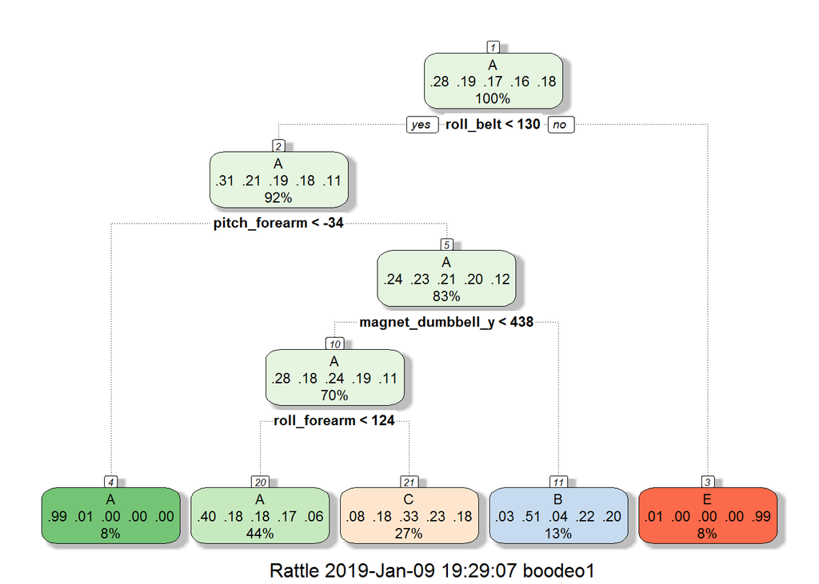

```r
fancyRpartPlot(model1$finalModel)
```

Based on the confusion matrix, the decision tree method seems not fully capable of making accurate predictions. The out of sample error is quite high at 51%, resulting in low prediction accuracy.

#### Model 2: Linear discriminant analysis

```r
set.seed(1234)
modlda <- train(classe ~.,data = training, method = "lda", trControl = tc)
plda <- predict(modlda, testing)
confusionMatrix(plda, testing$classe)
```

```
## Confusion Matrix and Statistics
##
##           Reference
## Prediction    A    B    C    D    E
##          A 1144  145   79   48   30
##          B   30  598   93   41  149
##          C  109  121  559   85   70
##          D  107   35   98  600   96
##          E    5   50   26   30  556
##
## Overall Statistics
##
##                Accuracy : 0.7049
##                  95% CI : (0.6919, 0.7177)
##     No Information Rate : 0.2845
##     P-Value [Acc > NIR] : < 2.2e-16
##
##                   Kappa : 0.6267
##  Mcnemar's Test P-Value : < 2.2e-16
##
## Statistics by Class:
##
##                      Class: A Class: B Class: C Class: D Class: E
## Sensitivity            0.8201   0.6301   0.6538   0.7463   0.6171
## Specificity            0.9139   0.9209   0.9049   0.9180   0.9723
## Pos Pred Value         0.7911   0.6564   0.5922   0.6410   0.8336
## Neg Pred Value         0.9274   0.9121   0.9253   0.9486   0.9186
## Prevalence             0.2845   0.1935   0.1743   0.1639   0.1837
## Detection Rate         0.2333   0.1219   0.1140   0.1223   0.1134
## Detection Prevalence   0.2949   0.1858   0.1925   0.1909   0.1360
## Balanced Accuracy      0.8670   0.7755   0.7794   0.8322   0.7947
```

#### Comparing model 1 to model 2

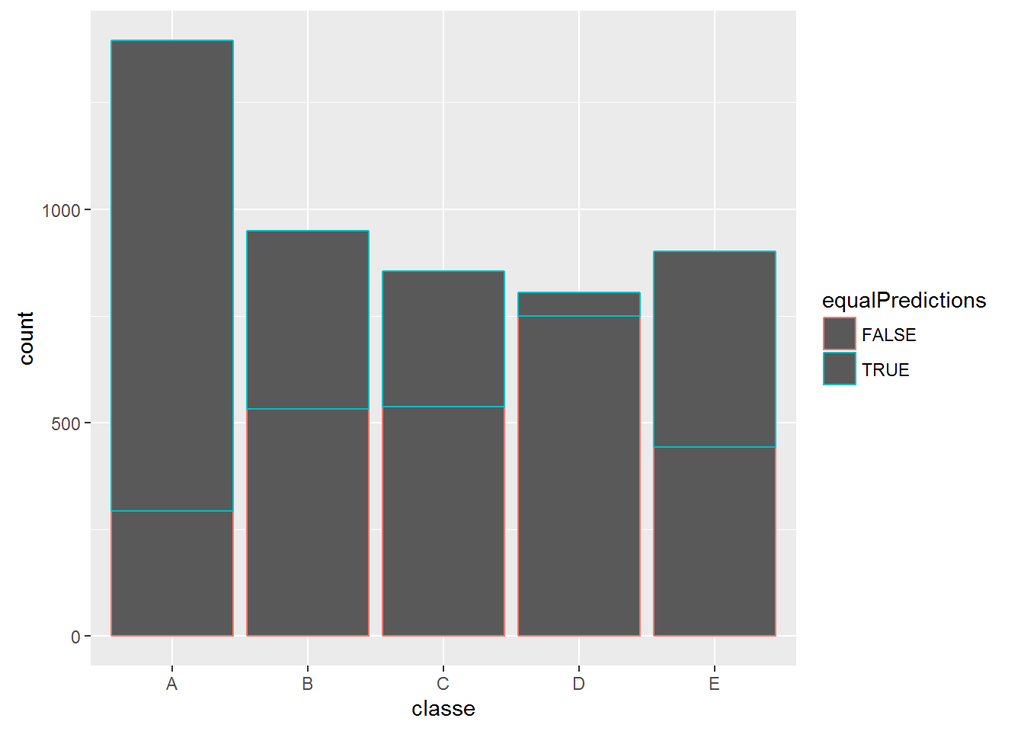

```r
equalPredictions <- (pred1 == plda)
qplot(classe, color = equalPredictions, data = testing)
```

The graph above shows that these two methods produce quite diverging predictions about the outcome. It is therefore worth investigating further with a different model.

#### Model 3: Predicting with Random Forests

```r
set.seed(8976)
model3 <- randomForest(classe ~.,data = training, method = "class", trControl = tc)
predrf <- predict(model3, testing, type = "class")
confusionMatrix(predrf, testing$classe)
```

```
## Confusion Matrix and Statistics
##
##           Reference
## Prediction    A    B    C    D    E
##          A 1394    2    0    0    0
##          B    0  947    8    0    0
##          C    0    0  846   15    0
##          D    0    0    1  789    3
##          E    1    0    0    0  898
##
## Overall Statistics
##
##                Accuracy : 0.9939
##                  95% CI : (0.9913, 0.9959)
##     No Information Rate : 0.2845
##     P-Value [Acc > NIR] : < 2.2e-16
##
##                   Kappa : 0.9923
##  Mcnemar's Test P-Value : NA
##
## Statistics by Class:
##
##                      Class: A Class: B Class: C Class: D Class: E
## Sensitivity            0.9993   0.9979   0.9895   0.9813   0.9967
## Specificity            0.9994   0.9980   0.9963   0.9990   0.9998
## Pos Pred Value         0.9986   0.9916   0.9826   0.9950   0.9989
## Neg Pred Value         0.9997   0.9995   0.9978   0.9964   0.9993
## Prevalence             0.2845   0.1935   0.1743   0.1639   0.1837
## Detection Rate         0.2843   0.1931   0.1725   0.1609   0.1831
## Detection Prevalence   0.2847   0.1947   0.1756   0.1617   0.1833
## Balanced Accuracy      0.9994   0.9979   0.9929   0.9902   0.9982
```

#### Appendix

Predicting new values

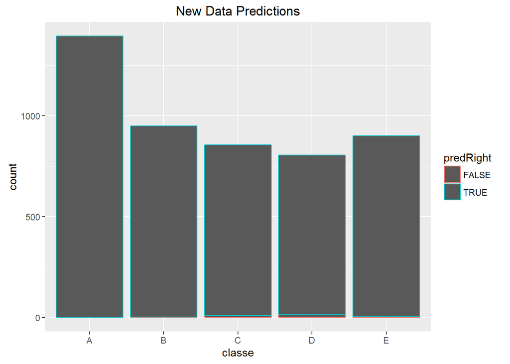

```r
testing$predRight <- predrf==testing$classe
qplot(classe, color = predRight, data = testing, main = "New Data Predictions")
```